# Tutorial 3

# Libraries

```r
library(psych)
library(GPArotation)
library(reshape2)
library(ggplot2)
library(magrittr)
library(dplyr)
library(tidyverse)
library(cowplot)
library(MASS)
```

# Data

```r
eg<-read.csv("/Users/jasonchan/MSTAT/STAT8019_Marketing_Analytics/tutorial notes/t3_data/TUT05.csv")

load("/Users/jasonchan/MSTAT/STAT8019_Marketing_Analytics/tutorial notes/t3_data/TUT0502.RData")
```

# Question 3

```r
eg$Y<-factor(eg$Y,labels=c("PCCW","NWT","Pacific"))
head(eg)
```

|  | ID | income | age | edu | expense | hour | Y |
| --- | --- | --- | --- | --- | --- | --- | --- |
| 1 | 1 | 18800 | 44 | 17 | 600 | 7 | Pacific |
| 2 | 2 | 14300 | 36 | 15 | 100 | 4 | PCCW |
| 3 | 3 | 12000 | 36 | 16 | 600 | 8 | PCCW |
| 4 | 4 | 12000 | 30 | 16 | 400 | 6 | PCCW |
| 5 | 5 | 16600 | 41 | 17 | 750 | 7 | Pacific |
| 6 | 6 | 34700 | 47 | 18 | 720 | 9 | NWT |

## Part (b) and (c)

```r
fit <- principal(r=eg[, 2:6], nfactors = 5, rotate = "None")
```

```
Specified rotation not found, rotate='none' used
```

```r
fit
```

```
Principal Components Analysis
Call: principal(r = eg[, 2:6], nfactors = 5, rotate = "None")
Standardized loadings (pattern matrix) based upon correlation matrix
```

|  | PC1 | PC2 | PC3 | PC4 | PC5 | h2 | u2 | com |
| --- | --- | --- | --- | --- | --- | --- | --- | --- |
| income | 0.85 | -0.27 | 0.27 | -0.03 | -0.37 | 1 | -1.332268e-15 | 1.852185 |
| age | 0.79 | -0.49 | 0.13 | -0.07 | 0.34 | 1 | 1.221245e-15 | 2.174978 |
| edu | 0.84 | -0.03 | -0.38 | 0.39 | -0.03 | 1 | 6.661338e-16 | 1.879222 |
| expense | 0.82 | 0.26 | -0.31 | -0.40 | -0.02 | 1 | 6.661338e-16 | 2.041006 |
| hour | 0.70 | 0.60 | 0.34 | 0.12 | 0.12 | 1 | 2.220446e-16 | 2.592043 |

```
                       PC1  PC2  PC3  PC4  PC5
SS loadings           3.20 0.74 0.45 0.34 0.27
Proportion Var        0.64 0.15 0.09 0.07 0.05
Cumulative Var        0.64 0.79 0.88 0.95 1.00
Proportion Explained  0.64 0.15 0.09 0.07 0.05
Cumulative Proportion 0.64 0.79 0.88 0.95 1.00

Mean item complexity =  2.1
Test of the hypothesis that 5 components are sufficient.

The root mean square of the residuals (RMSR) is  0
 with the empirical chi square  0  with prob <  NA

Fit based upon off diagonal values = 1
```

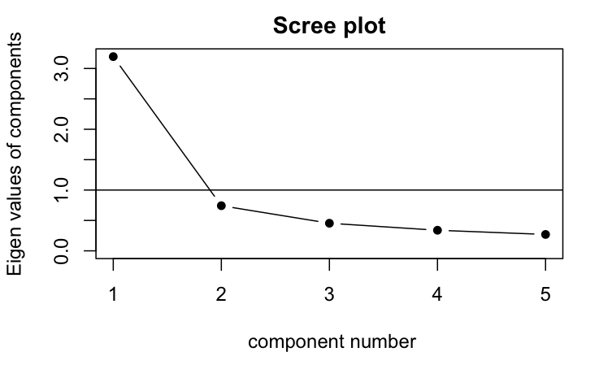

```r
scree(rx=eg[, 2:6], factors = FALSE)
```

- From above, `m=2` is then chosen

## Part (d)

```r
fit <- principal(r=eg[, 2:6], nfactors = 2, rotate = "None")
```

```
Specified rotation not found, rotate='none' used
```

```r
fit$communality
```

```
   income       age       edu   expense      hour
0.7859982 0.8609008 0.6987892 0.7390736 0.8529512
```

## Part (e)

```r
fitr <- principal(r=eg[, 2:6], nfactors = 2, rotate = "varimax")
fitr
```

```
Principal Components Analysis
Call: principal(r = eg[, 2:6], nfactors = 2, rotate = "varimax")
Standardized loadings (pattern matrix) based upon correlation matrix
```

|  | RC1 | RC2 | h2 | u2 | com |
| --- | --- | --- | --- | --- | --- |
| income | 0.82 | 0.34 | 0.7859982 | 0.2140018 | 1.333410 |
| age | 0.92 | 0.14 | 0.8609008 | 0.1390992 | 1.044478 |
| edu | 0.66 | 0.51 | 0.6987892 | 0.3012108 | 1.887963 |
| expense | 0.46 | 0.73 | 0.7390736 | 0.2609264 | 1.682705 |
| hour | 0.15 | 0.91 | 0.8529512 | 0.1470488 | 1.051213 |

```
                       RC1  RC2
SS loadings           2.18 1.76
Proportion Var        0.44 0.35
Cumulative Var        0.44 0.79
Proportion Explained  0.55 0.45
Cumulative Proportion 0.55 1.00

Mean item complexity =  1.4
Test of the hypothesis that 2 components are sufficient.

The root mean square of the residuals (RMSR) is  0.09
 with the empirical chi square  2.96  with prob <  0.085

Fit based upon off diagonal values = 0.98
```

- Communality and % total variance explained remains the same

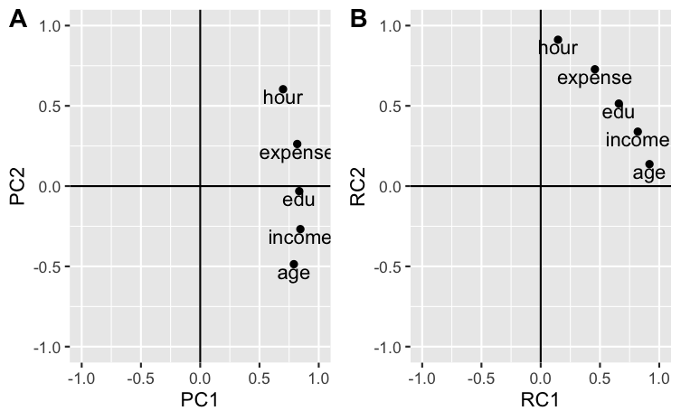

```r
#plot of factor loadings
ld<-data.frame(fit$loadings[,1:2])

no_rot <- ggplot(data=ld,aes(x=PC1,y=PC2))+
  geom_point()+
  geom_text(aes(label=rownames(ld),vjust=1))+
  geom_vline(aes(xintercept=0))+
  geom_hline(aes(yintercept=0))+
  coord_cartesian(xlim = c(-1,1),ylim=c(-1,1))

ld_rot<-data.frame(fitr$loadings[,1:2])

rot <- ggplot(data=ld_rot,aes(x=RC1,y=RC2))+
  geom_point()+
  geom_text(aes(label=rownames(ld),vjust=1))+
  geom_vline(aes(xintercept=0))+
  geom_hline(aes(yintercept=0))+
  coord_cartesian(xlim = c(-1,1),ylim=c(-1,1))

plot_grid(no_rot, rot, labels = "AUTO")
```

- All loadings became positive after rotation of anti-clockwise

## Part (f)

```r
round(ld_rot, 2)
```

|  | RC1 | RC2 |
| --- | --- | --- |
| income | 0.82 | 0.34 |
| age | 0.92 | 0.14 |
| edu | 0.66 | 0.51 |
| expense | 0.46 | 0.73 |
| hour | 0.15 | 0.91 |

- F1 loads heavy on age, income, edu (background factor)
- F2 loads heavy on hour and expense (service usage factor)

The FA model is as follows:

$$Z_{income} = 0.82F^*_1 + 0.34F^*_2$$
$$Z_{age} = 0.92F^*_1 + 0.14F^*_2$$
$$Z_{edu} = 0.66F^*_1 + 0.51F^*_2$$
$$Z_{expense} = 0.46F^*_1 + 0.73F^*_2$$

$$Z_{hour} = 0.15F^*_1 + 0.91F^*_2$$

## Part (g)

```r
round(fitr$weights, 2)
```

```
          RC1   RC2
income   0.43 -0.11
age      0.61 -0.34
edu      0.23  0.14
expense -0.03  0.44
hour    -0.36  0.76
```

Based on the above,

```r
head(fitr$scores)
```

```
            RC1         RC2
[1,]  0.5919085 -0.76003583
[2,] -0.2079687 -2.62702538
[3,] -0.8476492 -0.02886436
[4,] -1.0920574 -0.82380111
[5,]  0.1565242 -0.19749412
[6,]  1.6215513 -0.13164578
```

## Part (h) Perceptual Map

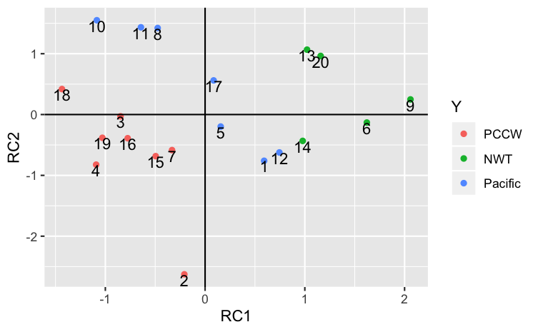

```r
sc<-data.frame(fitr$scores,Y=eg$Y)
ggplot(data=sc,aes(x=RC1,y=RC2))+
  geom_point(aes(color=Y))+
  geom_text(aes(label=eg$ID,vjust=1))+
  geom_vline(aes(xintercept=0))+
  geom_hline(aes(yintercept=0))
```

## Part (i)

- The PCCW users (-ve factor 1 and factor 2 scores) tend to be young, low income and less educated. Most of them do not spend a lot of money and time on internet services.
- For New World users (+ve factor 1 score), they are old, high income and highly educated. Some of them may spent a lot of time and money on internet while some of them may not.
- For Pacific Internet users, their levels of attributes are just in between these two groups. Therefore, their behavior is the combination of these two groups of users.

# Question 4

```r
head(x)
```

```
          [,1]      [,2]      [,3]     [,4]     [,5]     [,6]
[1,] -7.729677 -7.627074 -7.810508 7.564455 8.082915 7.725091
[2,] -8.873449 -8.235669 -7.990702 7.110645 6.572368 6.827453
[3,] -7.156738 -7.015756 -7.212173 7.090637 6.852257 7.229381
[4,] -7.575314 -7.651944 -7.302529 8.600309 8.823060 7.792810
[5,] -6.237886 -8.685084 -7.497031 7.424549 8.714493 8.853714
[6,] -8.234482 -6.898464 -7.456600 6.859027 6.502006 6.794227
            [,7]       [,8]       [,9]
[1,] -0.67717666 -0.5776357 -0.1711751
[2,] -0.07818015  0.1094597 -0.5229108
[3,]  1.00476061  1.0439327  1.6277801
[4,]  0.60166189 -0.2091776 -0.2780777
[5,]  0.18130612 -0.6614749  0.3852820
[6,]  1.09689563  1.2783838  1.8624940
```

## Part (a)

### Scree Plot

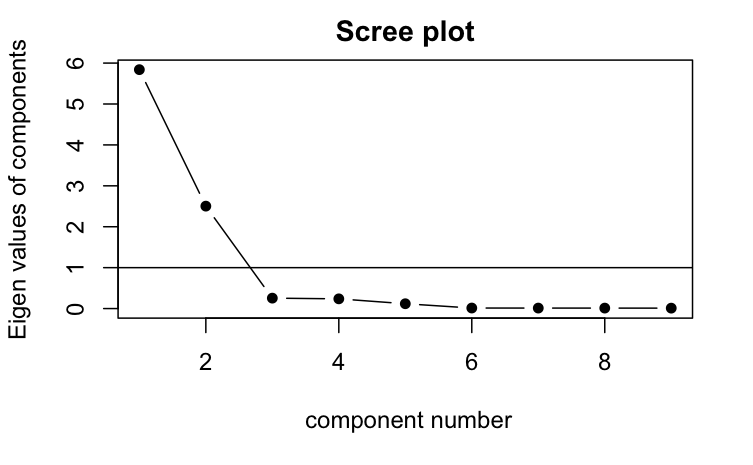

```r
scree(x, factors = FALSE)
```

```r
# shouldn't we use covar = TRUE?
fit<-principal(r=x, nfactors=9,rotate="none")
fit
```

```
Principal Components Analysis
Call: principal(r = x, nfactors = 9, rotate = "none")
Standardized loadings (pattern matrix) based upon correlation matrix
```

|  | PC1 | PC2 | PC3 | PC4 | PC5 | PC6 | PC7 | PC8 | PC9 | h2 | u2 | com |
| --- | --- | --- | --- | --- | --- | --- | --- | --- | --- | --- | --- | --- |
| 1 | 0.98 | -0.03 | 0.03 | 0.01 | 0.14 | 0.05 | -0.06 | -0.04 | 0.02 | 1 | 2.220446e-16 | 1.062187 |
| 2 | 0.99 | -0.03 | 0.04 | 0.01 | 0.13 | -0.01 | 0.07 | 0.01 | 0.05 | 1 | 2.886580e-15 | 1.055094 |
| 3 | 0.98 | -0.03 | 0.03 | 0.01 | 0.14 | -0.04 | -0.01 | 0.03 | -0.07 | 1 | 6.661338e-16 | 1.061983 |
| 4 | -0.99 | 0.02 | 0.03 | 0.01 | 0.13 | 0.03 | 0.04 | -0.06 | -0.04 | 1 | 7.771561e-16 | 1.056660 |
| 5 | -0.99 | 0.03 | 0.04 | 0.01 | 0.13 | 0.05 | -0.01 | 0.07 | 0.01 | 1 | 5.551115e-16 | 1.058294 |
| 6 | -0.98 | 0.03 | 0.04 | 0.00 | 0.15 | -0.08 | -0.03 | -0.02 | 0.03 | 1 | 9.992007e-16 | 1.066338 |
| 7 | 0.08 | 0.91 | 0.10 | -0.39 | 0.00 | 0.00 | 0.00 | 0.00 | 0.00 | 1 | 6.661338e-16 | 1.388361 |
| 8 | 0.04 | 0.91 | -0.39 | 0.11 | 0.04 | 0.00 | 0.00 | 0.00 | 0.00 | 1 | 9.992007e-16 | 1.400757 |
| 9 | 0.07 | 0.91 | 0.29 | 0.27 | -0.04 | 0.00 | 0.00 | 0.00 | 0.00 | 1 | 6.661338e-16 | 1.418797 |

```
                       PC1  PC2  PC3  PC4  PC5  PC6
SS loadings           5.84 2.50 0.25 0.24 0.12 0.01
Proportion Var        0.65 0.28 0.03 0.03 0.01 0.00
Cumulative Var        0.65 0.93 0.96 0.98 0.99 1.00
Proportion Explained  0.65 0.28 0.03 0.03 0.01 0.00
Cumulative Proportion 0.65 0.93 0.96 0.98 0.99 1.00
                       PC7  PC8  PC9
SS loadings           0.01 0.01 0.01
Proportion Var        0.00 0.00 0.00
Cumulative Var        1.00 1.00 1.00
Proportion Explained  0.00 0.00 0.00
Cumulative Proportion 1.00 1.00 1.00

Mean item complexity =  1.2
Test of the hypothesis that 9 components are sufficient.

The root mean square of the residuals (RMSR) is  0
 with the empirical chi square  0  with prob <  NA

Fit based upon off diagonal values = 1
```

- Based on scree plot and latent root, 2 factors are suggested

### 2 Factor Solution

```r
fitr<-principal(r=x, nfactors=2,rotate="varimax")
fitr
```

```
Principal Components Analysis
Call: principal(r = x, nfactors = 2, rotate = "varimax")
Standardized loadings (pattern matrix) based upon correlation matrix
```

|  | RC1 | RC2 | h2 | u2 | com |
| --- | --- | --- | --- | --- | --- |
| 1 | 0.98 | -0.03 | 0.9712679 | 0.02873211 | 1.002464 |
| 2 | 0.99 | -0.03 | 0.9742604 | 0.02573961 | 1.001794 |
| 3 | 0.98 | -0.03 | 0.9710842 | 0.02891580 | 1.001936 |
| 4 | -0.99 | 0.02 | 0.9732301 | 0.02676992 | 1.001202 |
| 5 | -0.99 | 0.03 | 0.9729687 | 0.02703135 | 1.002214 |
| 6 | -0.98 | 0.03 | 0.9689426 | 0.03105736 | 1.001648 |
| 7 | 0.08 | 0.91 | 0.8412983 | 0.15870165 | 1.014156 |
| 8 | 0.04 | 0.91 | 0.8327962 | 0.16720378 | 1.004499 |
| 9 | 0.07 | 0.91 | 0.8372666 | 0.16273339 | 1.013358 |

```
                       RC1  RC2
SS loadings           5.84 2.50
Proportion Var        0.65 0.28
Cumulative Var        0.65 0.93
Proportion Explained  0.70 0.30
Cumulative Proportion 0.70 1.00

Mean item complexity =  1
Test of the hypothesis that 2 components are sufficient.

The root mean square of the residuals (RMSR) is  0.03
 with the empirical chi square  20.6  with prob <  0.36

Fit based upon off diagonal values = 1
```

### 3 Factor Solution

```r
fitr<-principal(r=x, nfactors=3,rotate="varimax")
fitr
```

```
Principal Components Analysis
Call: principal(r = x, nfactors = 3, rotate = "varimax")
Standardized loadings (pattern matrix) based upon correlation matrix
```

|  | RC1 | RC2 | RC3 | h2 | u2 | com |
| --- | --- | --- | --- | --- | --- | --- |
| 1 | 0.99 | 0.01 | -0.03 | 0.9720052 | 0.02799479 | 1.002199 |
| 2 | 0.99 | 0.01 | -0.04 | 0.9755784 | 0.02442163 | 1.003717 |
| 3 | 0.99 | 0.01 | -0.03 | 0.9719468 | 0.02805322 | 1.002598 |
| 4 | -0.99 | -0.01 | -0.03 | 0.9741104 | 0.02588958 | 1.001631 |
| 5 | -0.99 | 0.00 | -0.03 | 0.9742043 | 0.02579570 | 1.001893 |
| 6 | -0.98 | 0.00 | -0.04 | 0.9705946 | 0.02940539 | 1.002784 |
| 7 | 0.04 | 0.92 | 0.03 | 0.8506516 | 0.14934835 | 1.006400 |
| 8 | 0.01 | 0.85 | 0.51 | 0.9854407 | 0.01455925 | 1.647890 |
| 9 | 0.04 | 0.95 | -0.16 | 0.9233914 | 0.07660860 | 1.062337 |

```
                       RC1  RC2  RC3
SS loadings           5.83 2.46 0.30
Proportion Var        0.65 0.27 0.03
Cumulative Var        0.65 0.92 0.96
Proportion Explained  0.68 0.29 0.03
Cumulative Proportion 0.68 0.97 1.00

Mean item complexity =  1.1
Test of the hypothesis that 3 components are sufficient.

The root mean square of the residuals (RMSR) is  0.02
 with the empirical chi square  15.27  with prob <  0.23

Fit based upon off diagonal values = 1
```

## Part (b)

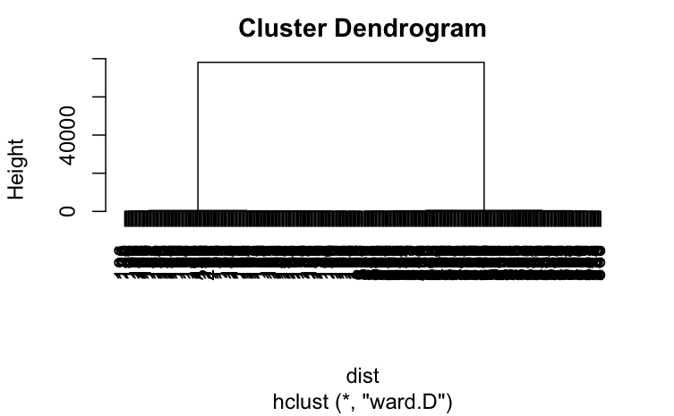

```r
#b
dist<-dist(x,method="euclidean")^2
fit <- hclust(dist, method="ward.D")
plot(fit)
```

- 2 Clusters suggested

```r
sol<-cutree(fit,k=2)
print(aggregate(x,by=list(cluster=sol),FUN=mean),digits=2)
```

| cluster | V1 | V2 | V3 | V4 | V5 | V6 | V7 | V8 | V9 |
| --- | --- | --- | --- | --- | --- | --- | --- | --- | --- |
| 1 | -7.96883630 | -7.99823156 | -8.03006834 | 8.04553156 | 8.0574382 | 8.04063197 | -0.06304928 | 0.01999631 | -0.02088780 |
| 2 | 0.03867586 | 0.02833415 | 0.08973315 | -0.00114478 | -0.0640661 | -0.04662036 | 0.02679958 | 0.06457095 | 0.06242504 |

## Part (c)

Construct FA using PC method for each of the 2 clusters.

### Cluster 1

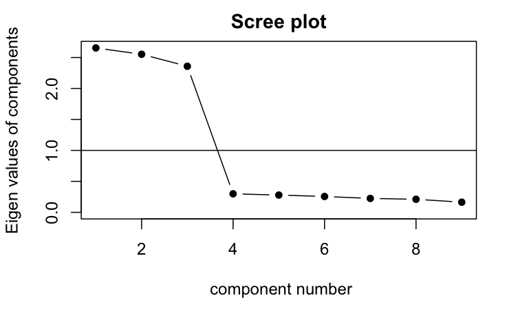

```r
scree(rx=x[sol==1, ], factors = F)
```

```r
principal(x[sol==1, ], nfactors = 9, rotate = "none")
```

```
Principal Components Analysis
Call: principal(r = x[sol == 1, ], nfactors = 9, rotate = "none")
Standardized loadings (pattern matrix) based upon correlation matrix
```

|  | PC1 | PC2 | PC3 | PC4 | PC5 | PC6 | PC7 | PC8 | PC9 | h2 | u2 | com |
| --- | --- | --- | --- | --- | --- | --- | --- | --- | --- | --- | --- | --- |
| 1 | 0.51 | 0.62 | 0.44 | 0.10 | 0.07 | -0.27 | 0.14 | 0.22 | 0.05 | 1 | 5.551115e-16 | 3.788803 |
| 2 | 0.62 | 0.56 | 0.39 | 0.08 | 0.05 | 0.34 | 0.05 | 0.01 | -0.17 | 1 | 2.220446e-15 | 3.579238 |
| 3 | 0.52 | 0.60 | 0.47 | -0.18 | -0.06 | -0.06 | -0.16 | -0.25 | 0.14 | 1 | 1.110223e-15 | 3.870906 |
| 4 | -0.74 | 0.18 | 0.53 | -0.02 | 0.19 | 0.18 | -0.11 | 0.15 | 0.21 | 1 | -4.440892e-16 | 2.617686 |
| 5 | -0.70 | 0.12 | 0.57 | 0.29 | 0.04 | -0.07 | 0.13 | -0.24 | -0.05 | 1 | -1.554312e-15 | 2.790271 |
| 6 | -0.64 | 0.19 | 0.63 | -0.27 | -0.20 | -0.06 | -0.01 | 0.09 | -0.19 | 1 | -8.881784e-16 | 3.014894 |
| 7 | 0.33 | -0.67 | 0.54 | 0.12 | 0.14 | -0.11 | -0.30 | 0.03 | -0.12 | 1 | -2.220446e-16 | 3.251659 |
| 8 | 0.29 | -0.73 | 0.45 | -0.25 | 0.23 | 0.01 | 0.24 | -0.07 | 0.02 | 1 | 0.000000e+00 | 2.913769 |
| 9 | 0.30 | -0.66 | 0.55 | 0.13 | -0.35 | 0.10 | 0.06 | 0.06 | 0.13 | 1 | 0.000000e+00 | 3.307290 |

```
                       PC1  PC2  PC3  PC4  PC5  PC6  PC7  PC8  PC9
SS loadings           2.65 2.55 2.36 0.30 0.28 0.26 0.22 0.21 0.16
Proportion Var        0.29 0.28 0.26 0.03 0.03 0.03 0.02 0.02 0.02
Cumulative Var        0.29 0.58 0.84 0.87 0.90 0.93 0.96 0.98 1.00
Proportion Explained  0.29 0.28 0.26 0.03 0.03 0.03 0.02 0.02 0.02
Cumulative Proportion 0.29 0.58 0.84 0.87 0.90 0.93 0.96 0.98 1.00

Mean item complexity =  3.2
Test of the hypothesis that 9 components are sufficient.

The root mean square of the residuals (RMSR) is  0
 with the empirical chi square  0  with prob <  NA

Fit based upon off diagonal values = 1
```

```r
# rotated
principal(x[sol==1, ], nfactors = 3, rotate = "none")
```

```
Principal Components Analysis
Call: principal(r = x[sol == 1, ], nfactors = 3, rotate = "none")
Standardized loadings (pattern matrix) based upon correlation matrix
```

|  | PC1 | PC2 | PC3 | h2 | u2 | com |
| --- | --- | --- | --- | --- | --- | --- |
| 1 | 0.51 | 0.62 | 0.44 | 0.8413017 | 0.1586983 | 2.768602 |
| 2 | 0.62 | 0.56 | 0.39 | 0.8431115 | 0.1568885 | 2.685375 |
| 3 | 0.52 | 0.60 | 0.47 | 0.8538798 | 0.1461202 | 2.888551 |
| 4 | -0.74 | 0.18 | 0.53 | 0.8572165 | 0.1427835 | 1.947138 |
| 5 | -0.70 | 0.12 | 0.57 | 0.8320156 | 0.1679844 | 1.991048 |
| 6 | -0.64 | 0.19 | 0.63 | 0.8371113 | 0.1628887 | 2.169283 |
| 7 | 0.33 | -0.67 | 0.54 | 0.8487283 | 0.1512717 | 2.412395 |
| 8 | 0.29 | -0.73 | 0.45 | 0.8239879 | 0.1760121 | 2.036302 |
| 9 | 0.30 | -0.66 | 0.55 | 0.8279971 | 0.1720029 | 2.387775 |

```
                       PC1  PC2  PC3
SS loadings           2.65 2.55 2.36
Proportion Var        0.29 0.28 0.26
Cumulative Var        0.29 0.58 0.84
Proportion Explained  0.35 0.34 0.31
Cumulative Proportion 0.35 0.69 1.00

Mean item complexity =  2.4
Test of the hypothesis that 3 components are sufficient.

The root mean square of the residuals (RMSR) is  0.04
 with the empirical chi square  25.09  with prob <  0.014

Fit based upon off diagonal values = 0.99
```